# Predictive Barbell Lifts

Ted Powers

Jan 21, 2015

### Summary

Accelerometers were used to capture 6 participants doing Unilateral Dumbbell Biceps Curls. Participants were ask to perform the curls in 5 different ways or classes. Our model was created using the data from the accelerometers on the belt, forearm, arm, and dumbell. We are trying to predict the manner in which the curl was performed.

The following packages were used to obtain the predicted results along with the random seed set to 42.

```r
library(caret)
library(rattle)
library(gbm)
set.seed(42)
```

### Data

The training data for this project are available here:

https://d396qusza40orc.cloudfront.net/predmachlearn/pml-training.csv

The test data are available here:

https://d396qusza40orc.cloudfront.net/predmachlearn/pml-testing.csv

More information is available from the website here: http://groupware.les.inf.puc-rio.br/har (see the section on the Weight Lifting Exercise Dataset).

### Cleaning the Training-Set

Included in the dataset are featured columns that the authors used to characterize the performance classes. These columns of data features the max/min value, average, skewness, etc. of the performance class and are not relevant to include as a predictor. In addition to removing these featured columns, I looked but did not find columns that had near zero variance or lots of missing data. As a result, the number of predictors for ‘classe’ was reduced to 52.

While this reduction may reduce our accuracy for our testing set by allowing more in-sample errors, it has several added benefits.

- The processing speed and computational requirements are reduced.
- Reduces likelihood of overfitting the model to the training data and thus insuring that the out-of-sample errors are more accurate.

```r
# Remove all feature columns
featured.cols <- grep("^max|^min|^ampl|^var|^avg|^stdd|^ske|^kurt", names(raw.training))
training <- training[-featured.cols]

#Removed variables related with data acquisition (like: id, timestamps, individuals’ names, etc.)
training <- training[, -(1:7)]

#Removed all variables that had little variance
nearzero <- nearZeroVar(training, saveMetrics = TRUE)
training <- training[, !nearzero$nzv]

#Removed all variables that had more than 30% of the data missing
toberem <-sapply(colnames(training), function(x)
        if (sum(is.na(training[, x])) > 0.30 * nrow(training))
        {return(TRUE)}
        else{return(FALSE)})
training <- training[,!toberem]

rm(nearzero, toberem, featured.cols)
```

### Partioning the training set into two

The training data is partitioned into two data sets, 75% for training, 25% for testing:

```r
inTrain <- createDataPartition(y=training$classe, p=.75, list=FALSE)
testing <- training[-inTrain, ]
training <- training[inTrain, ]
rm(inTrain)
```

### Model Preprocessing and Cross Validation

All the predictors were plotted to identify any extreme values. An example is shown below. 9 row values were removed from the dataset.

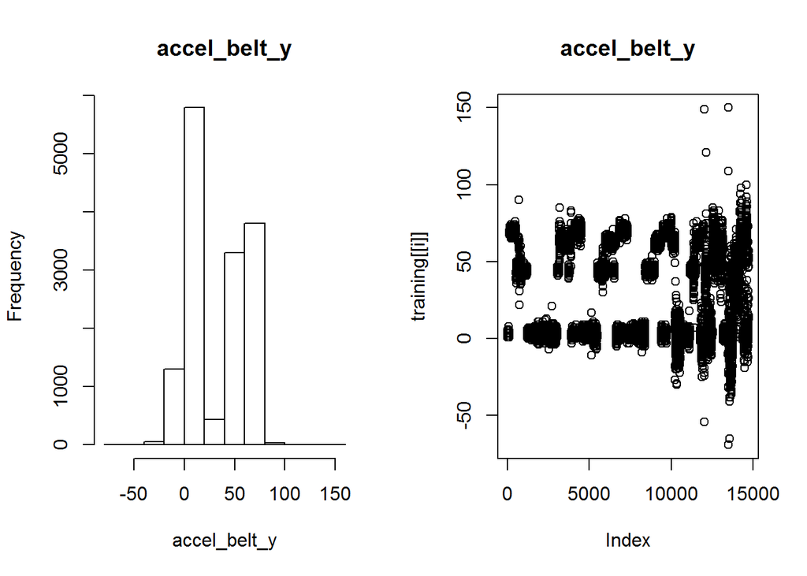

```r
# Explore plots to determine outliers
par(mfrow = c(1, 2))
for (i in 1:(ncol(training)-1)) {

    if (names(training[i]) == "accel_belt_y") {
        hist(training[[i]], xlab = names(training[i]), main = names(training[i]))
        plot(training[[i]], main = names(training[i]))
     }
}
```

```r
#Outliers values are removed
out.rows <- training$accel_belt_y > 100 | training$accel_belt_y < -50 | training$total_accel_dumbbell > 50 |
        training$gyros_dumbbell_x < -50 | training$gyros_dumbbell_y > 10 | training$gyros_dumbbell_z  > 10 |
        training$magnet_dumbbell_y < -2000 | training$total_accel_forearm > 90 | training$gyros_forearm_x < -10 |
        training$gyros_forearm_y > 50 | training$gyros_forearm_z > 50 | training$accel_forearm_y > 800
training <- training[!out.rows, ]
```

The number of variables is reduced to 26 by using Principle Component Analysis (PCA). PCA is used to avoid overfitting by combining highly correlated fields as well as reduce the computational requirements.

```r
#Shows how much pre-processing reduces the number of variables
preObj <- preProcess(x = training, method = "pca")
print(preObj)
```

```
## Created from 14709 samples and 53 variables
##
## Pre-processing:
##   - centered (52)
##   - ignored (1)
##   - principal component signal extraction (52)
##   - scaled (52)
##
## PCA needed 26 components to capture 95 percent of the variance
```

The introduction of a training control process performs the PCA reduction and adds a 7 fold cross validation. 7-fold cross validation avoids overfitting by breaking the training set into 7 subsets.

```r
tc <- trainControl(method = "cv", number = 7, verboseIter=FALSE , preProcOptions="pca", allowParallel=TRUE)
rm(i, out.rows, preObj)
```

### Model Selection

Three base models to cover a wide variety of possible distributions are used: Random Forest, Gradient Boosting, and Linear Discriminated Analysis model.

```r
rf.cv.model <- suppressMessages(train(classe ~ ., data = training, method = "rf", trControl= tc))
gbm.cv.model <- suppressMessages(train(classe ~., data = training, method="gbm", trControl = tc))
lda.cv.model <- suppressMessages(train(classe ~ ., data = training, method = "lda", trControl= tc))
```

Accuracy comparision

| model | Accuracy |
| --- | --- |
| Random Forest | 0.992045799687016 |
| Gradient Boosting | 0.961520414206334 |
| Linear Discriminate Analysis | 0.703041972843685 |

Random forest provides the best results and will provide the predictions for the submission. Even if the Out of sample error cannot be estimated exactly, the in-sample error obtained through cross-validation is calculated over different test sets and should provide a better estimate of out-of sample error with respect to the case of no cross-validation.

Checking our Predictions:

```r
confusionMatrix(rf.cv.Pred, testing$classe)
```

Confusion Matrix and Statistics

[output not shown]

Overall Statistics

```
           Accuracy : 0.9949
             95% CI : (0.9925, 0.9967)
No Information Rate : 0.2845
P-Value [Acc > NIR] : < 2.2e-16

              Kappa : 0.9936
```

Mcnemar’s Test P-Value : NA

Statistics by Class:

[output not shown]